# Homework 3 Solutions

Biostatistics 735 — Machine Learning in Public Health

Published

October 5, 2026

Setup and packages used.

```r
library(printr)
library(formatR)
library(kableExtra)
library(tidyverse)
library(rsample)
library(recipes)
library(yardstick)
library(caret)
library(broom)     # augment for residuals, leverage, cooks distance
library(lmtest)    # bptest for heteroscedasticity
library(glmnet)   # ridge/lasso
library(lars)     # diabetes data (public health: diabetes progression)
library(grpreg)   # grouped lasso
library(mlbench)
library(e1071)     # naiveBayes
library(rpart)     # CART

select <- dplyr::select

rmse <- function(truth, estimate) sqrt(mean((truth - estimate)^2))
```

# 1 Question 1

The dataset parkinsons data is composed of a range of biomedical voice measurements from 42 people with early-stage Parkinson’s disease recruited to a six-month trial of a telemonitoring device for remote symptom progression monitoring. The recordings were automatically captured in the patient’s homes. Columns in the table contain subject number, subject age, subject gender, time interval from baseline recruitment date, motor UPDRS, total UPDRS, and 16 biomedical voice measures. The attributes of the data are

- subject number - Integer that uniquely identifies each subject
- age - Subject age
- sex - Subject gender ‘0’ - male, ‘1’ - female
- test_time - Time since recruitment into the trial. The integer part is the number of days since recruitment.
- motor_UPDRS - Clinician’s motor UPDRS score, linearly interpolated
- total_UPDRS - Clinician’s total UPDRS score, linearly interpolated

16 biomedical voice measures

- Jitter(%), Jitter(Abs), Jitter:RAP, Jitter:PPQ5, Jitter:DDP - Several measures of variation in fundamental frequency
- Shimmer, Shimmer(dB), Shimmer:APQ3, Shimmer:APQ5, Shimmer:APQ11, Shimmer:DDA - Several measures of variation in amplitude
- NHR, HNR - Two measures of ratio of noise to tonal components in the voice
- RPDE - A nonlinear dynamical complexity measure
- DFA - Signal fractal scaling exponent
- PPE - A nonlinear measure of fundamental frequency variation

Each row corresponds to one of 5,875 voice recording from these individuals. The main aim of the data is to predict the motor and total UPDRS scores (‘motor_UPDRS’ and ‘total_UPDRS’) from the 16 voice measures.

1. (10 pts) Fit a grouped lasso regression predicting total UPDRS from the grouped voice predictors. For this question, use “Jitter”, “Shimmer”, etc. as the groups.
2. (10 pts) For each of the 16 biomedical voice measures, create quadratic and cubic transformations. Fit a grouped lasso with 16 groups, where each group will contain the linear, quadratic, and cubic forms for each of the 16 biomedical voice measures.
3. (5 pts) Fit a regular (non-grouped) lasso models from a, and b.
4. (5 pts) Compare the predictive performance of each of the four models fit in a – c.
5. (5 pts) How does grouped lasso differ from ordinary lasso in interpretation?

## 1.1 Part A

First, we’ll set out data up:

```r
parkinson <- read_csv("parkinsons_updrs.txt", show_col_types = FALSE)

set.seed(1234)

parkinson_UPDRS <- parkinson %>%
  dplyr::select(
    total_UPDRS, `Jitter(%)`:last_col()
  )
split_UPDRS <- initial_split(parkinson_UPDRS, prop = 0.7, strata = NULL)
train <- training(split_UPDRS)
test  <- testing(split_UPDRS)

X_tr <- as.matrix(dplyr::select(train, -total_UPDRS))
y_tr <- train$total_UPDRS
X_te <- as.matrix(dplyr::select(test,  -total_UPDRS))
y_te <- test$total_UPDRS


# group
grp_names <- c("Jitter(%)","Jitter(Abs)","Jitter:RAP","Jitter:PPQ5","Jitter:DDP",
               "Shimmer","Shimmer(dB)","Shimmer:APQ3","Shimmer:APQ5","Shimmer:APQ11",
               "Shimmer:DDA","NHR","HNR","RPDE","DFA","PPE")
gvec <- c(1,1,1,1,1, 2,2,2,2,2,2, 3,3, 4,5,6)
groups <- factor(gvec, labels = c("Jitter","Shimmer","Noise","RPDE","DFA","PPE"))
X_tr_g <- as.matrix(X_tr[, grp_names])
X_te_g <- as.matrix(X_te[, grp_names])
```

Now we’ll fit the grouped lasso:

```r
set.seed(412334)

cv_grp <- cv.grpreg(
  X_tr_g,
  y_tr,
  group = gvec,
  penalty = "grLasso",
  nfolds = 10,
  family = "gaussian")
#Fits the final group-lasso model at a specific penalty value lambda
grp_fit <- grpreg(
  X_tr_g,
  y_tr,
  group = gvec,
  penalty = "grLasso",
  lambda = cv_grp$lambda.min)

# Predictions on new data
pred_grp <- predict(grp_fit, X_te_g)
grp_rmse <- rmse(y_te, pred_grp)
grp_rmse %>% kable(digits = 4)
```

| x |
| --- |
| 9.9941 |

## 1.2 Part B

First, i’ll create the design matrix that will have the quadratic and cubic components.

```r
mu <- colMeans(X_tr_g)
s  <- apply(X_tr_g, 2, sd)

X_tr_std <- sweep(
  sweep(X_tr_g, 2, mu, "-"),
  2, s, "/"
)

X_te_std <- sweep(
  sweep(X_te_g, 2, mu, "-"),
  2, s, "/"
)

X_tr_g_poly <- cbind(X_tr_std, X_tr_std^2, X_tr_std^3)
X_te_g_poly <- cbind(X_te_std, X_te_std^2, X_te_std^3)

colnames(X_tr_g_poly) <- colnames(X_te_g_poly) <- c(
  colnames(X_tr_g),
  paste0(colnames(X_tr_g), "_sq"),
  paste0(colnames(X_tr_g), "_cub")
)
```

Now i’ll create the groups and fit the model:

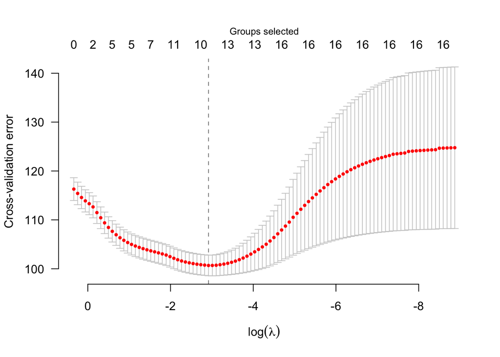

```r
# group
gvec_poly <- rep(1:ncol(X_tr_g),3)
groups_poly <- factor(gvec_poly,
                      labels = colnames(X_tr_g))

set.seed(412334)

cv_grp_poly <- cv.grpreg(
  X_tr_g_poly,
  y_tr,
  group = gvec_poly,
  penalty = "grLasso",
  nfolds = 10,
  family = "gaussian")
plot(cv_grp_poly)
```

```r
#Fits the final group-lasso model at a specific penalty value lambda
grp_fit_poly <- grpreg(
  X_tr_g_poly,
  y_tr,
  group = gvec_poly,
  penalty = "grLasso",
  lambda = cv_grp_poly$lambda.min)

# Predictions on new data
pred_grp_poly <- predict(grp_fit_poly, X_te_g_poly)
grp_poly_rmse <- rmse(y_te, pred_grp_poly)
grp_poly_rmse %>% kable(digits = 4)
```

| x |
| --- |
| 9.7955 |

## 1.3 Part C

We’ll compare with lasso using the data from (a):

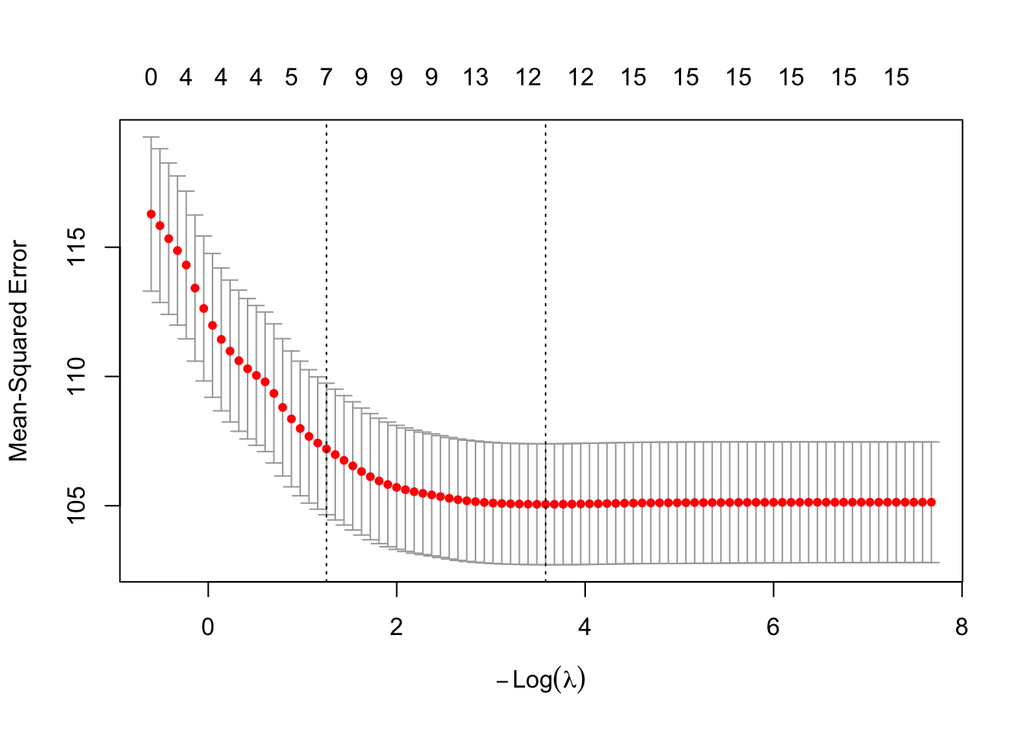

```r
# lasso
set.seed(2)
cv_lasso <- cv.glmnet(X_tr, y_tr, alpha = 1, standardize = TRUE, nfolds = 10)
plot(cv_lasso)
```

```r
# Fit lasso models at λ.min and λ.1se
lasso_fit_min <- glmnet(X_tr, y_tr, alpha = 1, lambda = cv_lasso$lambda.min, standardize = TRUE)
lasso_fit_1se <- glmnet(X_tr, y_tr, alpha = 1, lambda = cv_lasso$lambda.1se, standardize = TRUE)
# Prediction
pred_lasso_min <- predict(lasso_fit_min, X_te)
pred_lasso_1se <- predict(lasso_fit_1se , X_te)
# RMSE
lasso_rmse_min <- rmse(y_te, pred_lasso_min)
lasso_rmse_1se <- rmse(y_te, pred_lasso_1se)
```

Same with the data from (b):

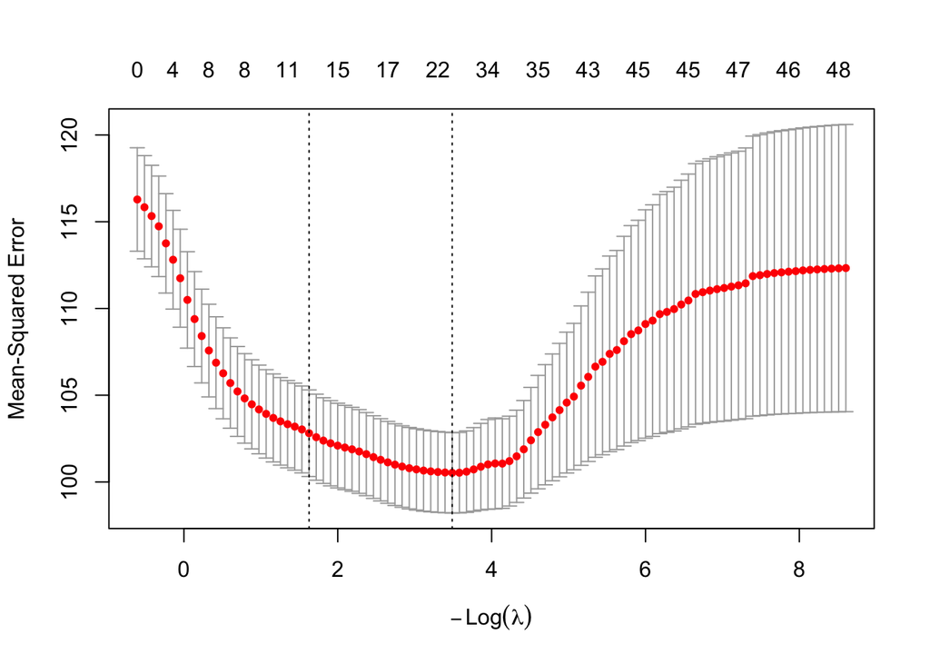

```r
# lasso
set.seed(2)
cv_lasso_poly <- cv.glmnet(X_tr_g_poly, y_tr, alpha = 1, standardize = TRUE, nfolds = 10)
plot(cv_lasso_poly)
```

```r
# Fit lasso models at λ.min and λ.1se
lasso_poly_fit_min <- glmnet(X_tr_g_poly, y_tr, alpha = 1, lambda = cv_lasso_poly$lambda.min, standardize = TRUE)
lasso_poly_fit_1se <- glmnet(X_tr_g_poly, y_tr, alpha = 1, lambda = cv_lasso_poly$lambda.1se, standardize = TRUE)
# Prediction
pred_lasso_poly_min <- predict(lasso_poly_fit_min, X_te_g_poly)
pred_lasso_poly_1se <- predict(lasso_poly_fit_1se , X_te_g_poly)
# RMSE
lasso_poly_rmse_min <- rmse(y_te, pred_lasso_poly_min)
lasso_poly_rmse_1se <- rmse(y_te, pred_lasso_poly_1se)
```

## 1.4 Part D

Let’s see the winner!!

```r
summ <- tibble(
  Method = c("Group Lasso", "Group Lasso Poly", "Lasso (min)", "Lasso (1SE)", "Lasso Poly (min)", "Lasso Poly (1SE)"),
  Test_RMSE = c(
    grp_rmse,
    grp_poly_rmse,
    lasso_rmse_min,
    lasso_rmse_1se,
    lasso_poly_rmse_min,
    lasso_poly_rmse_1se
  ),
  Nonzero = c(
    sum(coef(grp_fit)[-1] != 0),
    sum(coef(grp_fit_poly)[-1] != 0),
    sum(coef(lasso_fit_min)[-1] != 0),
    sum(coef(lasso_fit_1se)[-1] != 0),
    sum(coef(lasso_poly_fit_min)[-1] != 0),
    sum(coef(lasso_poly_fit_1se)[-1] != 0)
  )
) %>%
  arrange(Test_RMSE)
summ %>%
  kable(digits = 3, caption = "Grouped versus regular lasso with linear or polynomial transformations.") %>%
  kable_styling(full_width = FALSE)
```

Grouped versus regular lasso with linear or polynomial transformations.

| Method | Test_RMSE | Nonzero |
| --- | --- | --- |
| Lasso Poly (min) | 9.785 | 25 |
| Group Lasso Poly | 9.795 | 39 |
| Lasso Poly (1SE) | 9.867 | 14 |
| Group Lasso | 9.994 | 16 |
| Lasso (min) | 9.994 | 12 |
| Lasso (1SE) | 10.061 | 7 |

The polynomial transformations of the coefficients appear to be good for prediction. The lasso and group lasso with the polynomial data are the best 2 for predictive purposes. Let’s look at some of the coefficients:

```r
tibble(
  Variable = rownames(coef(lasso_poly_fit_min))[-1],
  Lasso.poly.min = as.vector(coef(lasso_poly_fit_min)[-1])
) |> left_join(
  tibble(
  Variable = names(coef(grp_fit_poly))[-1],
  GLasso.poly = as.vector(coef(grp_fit_poly)[-1]),
  Group = groups_poly
  )
) |> arrange(Group) |>
  dplyr::select(Variable, Group, everything()) |>
  kable(digits = 8, caption = "Coefficients for the two best model by group.") %>%
  kable_styling(full_width = FALSE)
```

Coefficients for the two best model by group.

| Variable | Group | Lasso.poly.min | GLasso.poly |
| --- | --- | --- | --- |
| Jitter(%) | Jitter(%) | 0.00237203 | 0.35744631 |
| Jitter(%)_sq | Jitter(%) | 0.00000000 | -0.09574874 |
| Jitter(%)_cub | Jitter(%) | 0.00000000 | 0.01099293 |
| Jitter(Abs) | Jitter(Abs) | -1.10164730 | -0.11690688 |
| Jitter(Abs)_sq | Jitter(Abs) | 0.00000000 | -0.29292708 |
| Jitter(Abs)_cub | Jitter(Abs) | 0.00140454 | 0.03044626 |
| Jitter:RAP | Jitter:RAP | 0.00000000 | -0.00024087 |
| Jitter:RAP_sq | Jitter:RAP | 0.11257887 | 0.00011544 |
| Jitter:RAP_cub | Jitter:RAP | 0.00000000 | -0.00000473 |
| Jitter:PPQ5 | Jitter:PPQ5 | 0.25427576 | 0.00000000 |
| Jitter:PPQ5_sq | Jitter:PPQ5 | 0.00000000 | 0.00000000 |
| Jitter:PPQ5_cub | Jitter:PPQ5 | 0.00000000 | 0.00000000 |
| Jitter:DDP | Jitter:DDP | 0.00000000 | 0.00000000 |
| Jitter:DDP_sq | Jitter:DDP | 0.00000000 | 0.00000000 |
| Jitter:DDP_cub | Jitter:DDP | 0.00000000 | 0.00000000 |
| Shimmer | Shimmer | 0.00000000 | 0.00000000 |
| Shimmer_sq | Shimmer | 0.18141050 | 0.00000000 |
| Shimmer_cub | Shimmer | 0.00000000 | 0.00000000 |
| Shimmer(dB) | Shimmer(dB) | 0.00000000 | -0.02171461 |
| Shimmer(dB)_sq | Shimmer(dB) | 0.00000000 | 0.01940434 |
| Shimmer(dB)_cub | Shimmer(dB) | 0.00000000 | -0.00260221 |
| Shimmer:APQ3 | Shimmer:APQ3 | -0.09256991 | -0.01590285 |
| Shimmer:APQ3_sq | Shimmer:APQ3 | 0.03068419 | 0.00395097 |
| Shimmer:APQ3_cub | Shimmer:APQ3 | 0.00000000 | -0.00037103 |
| Shimmer:APQ5 | Shimmer:APQ5 | -0.00088678 | -0.38824465 |
| Shimmer:APQ5_sq | Shimmer:APQ5 | 0.00000000 | 0.15318842 |
| Shimmer:APQ5_cub | Shimmer:APQ5 | 0.00000000 | -0.01217102 |
| Shimmer:APQ11 | Shimmer:APQ11 | 3.75561301 | 3.92242574 |
| Shimmer:APQ11_sq | Shimmer:APQ11 | -0.23579842 | -0.70971612 |
| Shimmer:APQ11_cub | Shimmer:APQ11 | 0.00000000 | 0.04499937 |
| Shimmer:DDA | Shimmer:DDA | -2.94465990 | -2.81676274 |
| Shimmer:DDA_sq | Shimmer:DDA | 0.08514658 | 0.69565050 |
| Shimmer:DDA_cub | Shimmer:DDA | 0.00000000 | -0.06532150 |
| NHR | NHR | -0.09852059 | -2.52443044 |
| NHR_sq | NHR | 0.08920794 | 0.75610756 |
| NHR_cub | NHR | 0.00000000 | -0.04255050 |
| HNR | HNR | -1.57178796 | -1.84688988 |
| HNR_sq | HNR | -1.68724660 | -1.51040176 |
| HNR_cub | HNR | 0.00000000 | -0.04093688 |
| RPDE | RPDE | -0.01245075 | -0.24846590 |
| RPDE_sq | RPDE | -0.32640413 | -0.28692261 |
| RPDE_cub | RPDE | 0.11423758 | 0.15116186 |
| DFA | DFA | -1.06661990 | -1.26541856 |
| DFA_sq | DFA | 0.00000000 | -0.05126539 |
| DFA_cub | DFA | -0.80518813 | -0.77770985 |
| PPE | PPE | 2.29381490 | 2.22444064 |
| PPE_sq | PPE | 0.87151936 | 1.03072097 |
| PPE_cub | PPE | -0.22497384 | -0.26971820 |

**Note**

The rows are repeated recordings on 42 people, so the random row-level split lets the same person land in both train and test. That makes all four RMSEs optimistic.

# 2 Question Two

**(15 points)** This question will use the *Communities and Crime* dataset from Homework 2.

- (5 pts) Fit a GAM predicting violent crime rate using smooth functions of at least three predictors (choose variables you believe might have nonlinear effects).
- (5 pts) Plot the smooth terms. Are any relationships clearly nonlinear?
- (5 pts) Compare predictive performance of the GAM to a linear model with the same predictors. Which has better predictions of the outcome?

## 2.1 Part A

To do this, I’m going to start by splitting the data into training and test data:

```r
library(mgcv)
# get data (this is a version I created for easier loading)
df.nomiss <- readRDS("community_crime.RDS")

set.seed(12345)
split_crime <- initial_split(df.nomiss, prop = 0.7, strata = NULL)


train <- training(split_crime)
test <- testing(split_crime)

# GAM with penalized B-spline smooths and REML smoothing selection
gam_model<-gam(ViolentCrime ~ s(MalePctDivorce) +
                 s(PctKids2Par) +
                 s(medIncome) +
                 s(PctIlleg),
               data = train, method = "REML")
summary(gam_model)
```

```
Family: gaussian
Link function: identity

Formula:
ViolentCrime ~ s(MalePctDivorce) + s(PctKids2Par) + s(medIncome) +
    s(PctIlleg)

Parametric coefficients:
            Estimate Std. Error t value Pr(>|t|)
(Intercept) 0.232079   0.003853   60.23   <2e-16 ***
---
Signif. codes:  0 '***' 0.001 '**' 0.01 '*' 0.05 '.' 0.1 ' ' 1

Approximate significance of smooth terms:
                    edf Ref.df      F  p-value
s(MalePctDivorce) 2.619  3.343  8.047 1.45e-05 ***
s(PctKids2Par)    2.067  2.689 16.164  < 2e-16 ***
s(medIncome)      3.308  4.150  4.028  0.00274 **
s(PctIlleg)       4.391  5.364 16.835  < 2e-16 ***
---
Signif. codes:  0 '***' 0.001 '**' 0.01 '*' 0.05 '.' 0.1 ' ' 1

R-sq.(adj) =  0.604   Deviance explained = 60.7%
-REML = -697.14  Scale est. = 0.020715  n = 1395
```

## 2.2 Part B

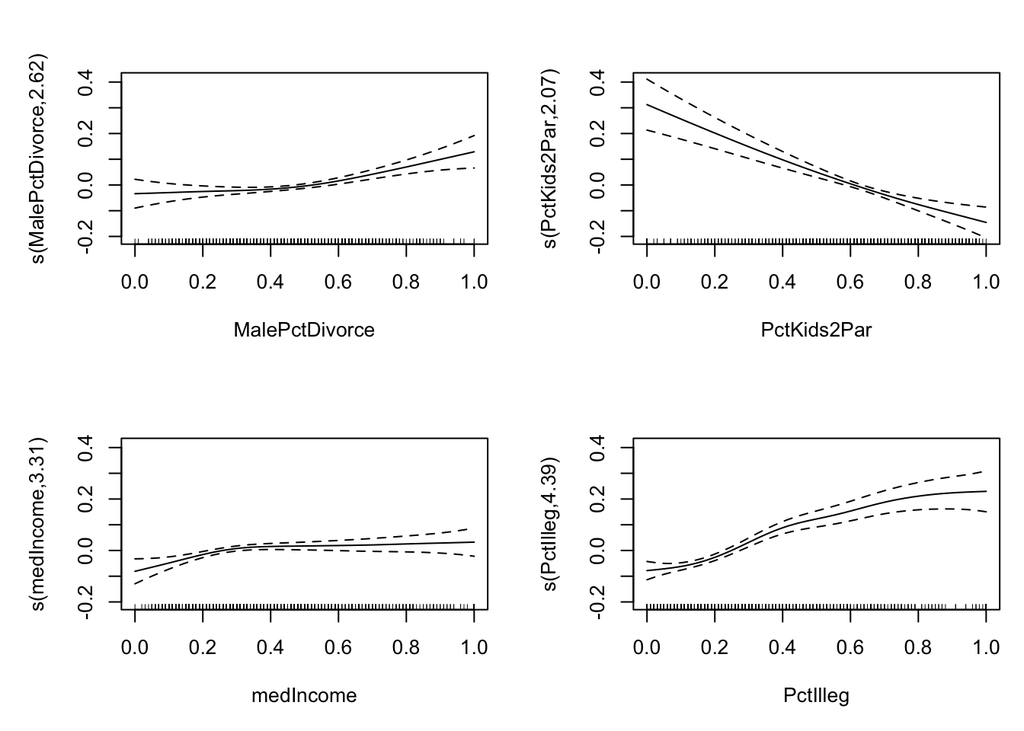

```r
plot(gam_model, pages = 1)
```

All 4 terms have a significant effect, but they are not equally non-linear. `PctIlleg` (S-shaped, flattening above about 0.7), `medIncome` (rises at low incomes, then plateaus), and `MalePctDivorce` (flat below about 0.5, increasing after that) show clear curvature. `PctKids2Par` is close to a straight line, even though its effective degrees of freedom (2.07) are slightly above 1. Let’s take a look at the predictions, and compare them with a linear only model.

## 2.3 Part C

```r
### Getting the RMSE for the GAM model
pred_gam <- predict(gam_model, test)
gam_rmse  <- rmse(test$ViolentCrime, pred_gam)


### Getting the RMSE for the linear only model
lin_only_model<-lm(ViolentCrime ~ MalePctDivorce +
                 PctKids2Par +
                 medIncome +
                 PctIlleg,
               data = train)
pred_lin_only <- predict(lin_only_model, test)
lin_only_rmse  <- rmse(test$ViolentCrime, pred_lin_only)


summ <- tibble(
  Method = c("Gam",
             "OLS w 4 Linear Pred"),
  Test_RMSE = c(
    gam_rmse,
    lin_only_rmse
  ),
  Approx_df = c(
    sum(gam_model$edf)-1,
    sum(coef(lin_only_model)[-1]!=0)
  )
)
summ %>% arrange(Test_RMSE) %>% kable(digits = 4)
```

| Method | Test_RMSE | Approx_df |
| --- | --- | --- |
| Gam | 0.1518 | 12.385 |
| OLS w 4 Linear Pred | 0.1534 | 4.000 |

The GAM with 4 smooth terms has a slightly lower test RMSE than the linear model with the same 4 predictors, so it predicts somewhat better. The improvement is small, though (about 1%), which is consistent with only mild curvature in most of the plots.

To estimate the number of coefficients for the GAM model I’m using the “effective degrees of freedom” summed over all coefficients. Here, this results in about 12 parameters (not counting the intercept), which is more than the the OLS with 4 linear predictors.

# 3 Question Three

**(50 points)** The dataset ``pima.indians.diabetes3.csv’’ contains data from 532 females who are at least 21 years of age and of Pima Indian heritage. The dataset consists of:

- `npregnant`: Number of times pregnant
- `glucose`: Plasma glucose concentration a 2 hours in an oral glucose tolerance test
- `diastolic.bp`: Diastolic blood pressure (mm Hg)
- `skinfold.thickness`: Triceps skin fold thickness (mm)
- `bmi`: Body mass index (weight in kg/(height in m)^2)
- `pedigree`: Diabetes pedigree function
- `age`: Age (years)
- `classdigit`: Numerical diabetes indicator
- `class`: Alphanumeric diabetes variable

The purpose of this study was to determine whether the patient exhibited *any* signs of diabetes mellitus according to World Health Organization criteria (i.e., if the 2-hour post-load plasma glucose level was at least 200 mg/dL at any survey examination or if it was detected during routine care). The two class variables indicate diabetes status using a blood test of 2-hour serum insulin. The goal is to use the other variables to predict diabetes status, as obtaining information on them is easier for patients, less invasive, and less expensive than a blood test. Use all other variables in each analysis.

You are to perform an analysis of this data. In terms of models, you should use at least 2 logistic regression based models (e.g., regular logistic regression, penalized logistic regression, etc.) and at least 2 non-logistic regression based (e.g., Naive Bayes, CART). Your analysis should demonstrate which candidate model has the *best predictive performance,* and provide an unbiased estimate of the best models predictive performance.

In terms of *best predictive performance,* consider the study goals in choosing the most appropriate predictive accuracy metric(s).

## 3.1 Analysis plan

Because the question is open ended, here is the plan I follow:

1. **Split once.** 80% of the data is a training set; the other 20% is a test set that is used **exactly once**, at the very end, for the final model only. Using the test set to compare models (and then reporting that same number for the winner) would give an optimistic estimate.
2. **Candidate models** (all use every predictor):
   - Logistic regression based: stepwise logistic regression (AIC and BIC) and logistic lasso (λ at the CV minimum and at the 1SE rule).
   - Not logistic regression based: **Naive Bayes** and **CART**.
3. **Compare the models with repeated 10-fold CV on the training data.** Every step that uses the outcome (standardizing, variable selection, tuning λ, pruning the tree, and choosing a classification threshold) is redone inside each fold, so the out-of-fold predictions are honest.
4. **Choose the best model** using the metrics that match the study goal, then refit it on the full training set and evaluate it once on the test set.

**Which metric?** The point of the model is to *screen* for diabetes with cheap measurements, so that the blood test can be reserved for those who need it. A missed case (false negative) is worse than an unnecessary follow-up blood test (false positive). So we care about **sensitivity and NPV**, but a threshold that calls everyone “diabetic” is useless. Therefore I (i) use the threshold-free **AUC** to compare how well each model ranks patients, and (ii) report sensitivity, specificity, PPV and NPV at a threshold chosen with **Youden’s index** (maximizes sensitivity + specificity − 1) from the training/CV data. Plain accuracy is not used, since about one third of the sample is diabetic.

## 3.2 Part A: Data and split

```r
pima <- read_csv("pima.indians.diabetes3.csv", show_col_types = FALSE) |>
  mutate(diabetes = factor(classdigit, levels = c(1, 0),
                           labels = c("diabetic", "normal"))) |>
  dplyr::select(-class, -classdigit)

colSums(is.na(pima))   # no missing data
```

```
         npregnant            glucose       diastolic.bp skinfold.thickness
                 0                  0                  0                  0
               bmi           pedigree                age           diabetes
                 0                  0                  0                  0
```

```r
set.seed(42)
split <- initial_split(pima, prop = 0.8, strata = diabetes)
train <- training(split)
test  <- testing(split)

bind_rows(train = table(train$diabetes), test = table(test$diabetes), .id = "set")
```

| set | diabetic | normal |
| --- | --- | --- |
| train | 141 | 284 |
| test | 36 | 71 |

`diabetic` is listed first in the factor so that `yardstick` treats it as the “event” (positive class) for sensitivity, PPV, etc.

## 3.3 Part B: Candidate models

Each model is written as a function that takes a training set and a new set and returns the predicted probability of diabetes for the new set. That way the *same* code is run inside every CV fold and for the final fit. Predictors are standardized using only the training rows given to the function (needed for the lasso; harmless for the stepwise models; Naive Bayes and CART don’t need it).

```r
xs <- setdiff(names(pima), "diabetes")

standardize <- function(tr, te) {
  mu <- colMeans(tr[xs]); s <- apply(tr[xs], 2, sd)
  f <- function(d) { d[xs] <- as.data.frame(scale(d[xs], mu, s)); d }
  list(tr = f(tr), te = f(te))
}

# Logistic regression: stepwise by AIC (k = 2) or BIC (k = log n)
fit_step <- function(tr, te, bic = FALSE) {
  z <- standardize(tr, te)
  d <- z$tr[xs]; d$y <- as.numeric(z$tr$diabetes == "diabetic")
  full <- glm(y ~ ., data = d, family = binomial())
  null <- glm(y ~ 1, data = d, family = binomial())
  fit <- MASS::stepAIC(null, scope = list(lower = null, upper = full),
                       direction = "both", k = if (bic) log(nrow(d)) else 2,
                       trace = FALSE)
  unname(predict(fit, z$te, type = "response"))
}

# Logistic lasso: lambda chosen by an inner 10-fold CV
fit_lasso <- function(tr, te, rule = "lambda.min") {
  z <- standardize(tr, te)
  cv <- cv.glmnet(as.matrix(z$tr[xs]), as.numeric(z$tr$diabetes == "diabetic"),
                  family = "binomial", alpha = 1, nfolds = 10,
                  type.measure = "deviance")
  as.numeric(predict(cv, as.matrix(z$te[xs]), s = rule, type = "response"))
}

# Naive Bayes: Gaussian class-conditional densities for each (numeric) predictor
fit_nb <- function(tr, te) {
  fit <- naiveBayes(diabetes ~ ., data = tr)
  predict(fit, te, type = "raw")[, "diabetic"]
}

# CART: grow a big tree, then prune at the cp with the smallest CV error
fit_cart <- function(tr, te) {
  fit <- rpart(diabetes ~ ., data = tr, method = "class",
               control = rpart.control(cp = 0.001, xval = 10))
  cp_best <- fit$cptable[which.min(fit$cptable[, "xerror"]), "CP"]
  predict(prune(fit, cp = cp_best), te, type = "prob")[, "diabetic"]
}

models <- list(
  "Logistic (AIC step)"  = \(a, b) fit_step(a, b),
  "Logistic (BIC step)"  = \(a, b) fit_step(a, b, bic = TRUE),
  "Lasso logistic (min)" = \(a, b) fit_lasso(a, b),
  "Lasso logistic (1SE)" = \(a, b) fit_lasso(a, b, "lambda.1se"),
  "Naive Bayes"          = fit_nb,
  "CART"                 = fit_cart
)
```

For reference, here are the variables the AIC and BIC stepwise searches pick on the full training set:

```r
z <- standardize(train, test)
d <- z$tr[xs]; d$y <- as.numeric(z$tr$diabetes == "diabetic")
full_glm <- glm(y ~ ., data = d, family = binomial())
null_glm <- glm(y ~ 1, data = d, family = binomial())
scope <- list(lower = null_glm, upper = full_glm)
formula(MASS::stepAIC(null_glm, scope = scope, direction = "both", trace = FALSE))
```

```
y ~ glucose + age + bmi + pedigree + npregnant
```

```r
formula(MASS::stepAIC(null_glm, scope = scope, direction = "both", k = log(nrow(d)), trace = FALSE))
```

```
y ~ glucose + age + bmi + pedigree
```

## 3.4 Part C: Compare models with repeated cross-validation (training data only)

We use 10-fold CV repeated 5 times (stratified on outcome). For every fold, each model is fit on 9/10 of the training data (including its own variable selection/tuning) and predicts the held-out 1/10.

```r
set.seed(2026)
folds <- vfold_cv(train, v = 10, repeats = 5, strata = diabetes)

oof <- map_dfr(seq_len(nrow(folds)), function(i) {
  a <- analysis(folds$splits[[i]])
  b <- assessment(folds$splits[[i]])
  map_dfr(names(models), \(m) tibble(model = m, rep = folds$id[i],
                                     truth = b$diabetes, prob = models[[m]](a, b)))
})
```

Now a function for Youden’s threshold and for the performance metrics. The threshold is chosen on the out-of-fold predictions (training data only). When several thresholds tie, I take the middle of them.

```r
youden_thr <- function(truth, prob) {
  grid <- sort(unique(c(0, prob, 1)))
  j <- map_dbl(grid, \(t) {
    p <- prob >= t
    mean(p[truth == "diabetic"]) + mean(!p[truth == "normal"]) - 1 })
  mean(range(grid[j >= max(j) - 1e-12]))
}

perf <- function(truth, prob, thr) {
  cls <- factor(ifelse(prob >= thr, "diabetic", "normal"), levels = levels(truth))
  c(AUC  = roc_auc_vec(truth, prob),
    Sens = sens_vec(truth, cls), Spec = spec_vec(truth, cls),
    PPV  = ppv_vec(truth, cls),  NPV  = npv_vec(truth, cls))
}

thr <- oof |> group_by(model) |> summarise(Threshold = youden_thr(truth, prob))

cv_res <- oof |>
  left_join(thr, by = "model") |>
  group_by(model, rep) |>
  summarise(as_tibble_row(perf(truth, prob, first(Threshold))),
            Threshold = first(Threshold), .groups = "drop") |>
  group_by(model) |>
  summarise(across(c(Threshold, AUC, Sens, Spec, PPV, NPV), mean)) |>
  arrange(desc(AUC))

cv_res |>
  kable(digits = 3, caption = "Cross-validated performance (training data, averaged over 5 repeats of 10-fold CV). Threshold chosen by Youden's index.") |>
  kable_styling(full_width = FALSE)
```

Cross-validated performance (training data, averaged over 5 repeats of 10-fold CV). Threshold chosen by Youden's index.

| model | Threshold | AUC | Sens | Spec | PPV | NPV |
| --- | --- | --- | --- | --- | --- | --- |
| Logistic (AIC step) | 0.264 | 0.837 | 0.799 | 0.716 | 0.583 | 0.877 |
| Lasso logistic (min) | 0.272 | 0.837 | 0.793 | 0.715 | 0.581 | 0.874 |
| Logistic (BIC step) | 0.280 | 0.830 | 0.776 | 0.744 | 0.601 | 0.870 |
| Lasso logistic (1SE) | 0.322 | 0.826 | 0.745 | 0.751 | 0.597 | 0.856 |
| Naive Bayes | 0.238 | 0.822 | 0.748 | 0.733 | 0.582 | 0.854 |
| CART | 0.280 | 0.762 | 0.623 | 0.818 | 0.631 | 0.814 |

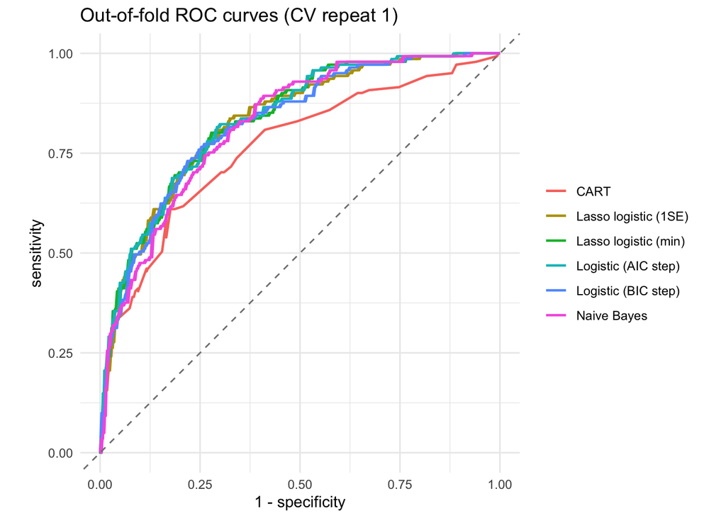

```r
oof |>
  filter(rep == "Repeat1") |>
  group_by(model) |>
  roc_curve(truth, prob) |>
  ggplot(aes(1 - specificity, sensitivity, color = model)) +
  geom_line(linewidth = 0.8) +
  geom_abline(linetype = 2, color = "grey50") +
  coord_equal() +
  labs(color = NULL, title = "Out-of-fold ROC curves (CV repeat 1)") +
  theme_minimal()
```

The logistic regression models (stepwise AIC and lasso with $\lambda_{min}$) are essentially tied at the top, with an AUC of about 0.84, followed closely by BIC, the 1SE lasso, and Naive Bayes (0.82). CART is clearly worst (AUC about 0.76, and sensitivity of only about 62%), which isn’t surprising for a single tree with a modest sample size. The differences among the top five models are small relative to the noise in these estimates, so the choice among them is not clear cut. Naive Bayes does well despite its independence assumption being violated (e.g., `age` and `npregnant`, `bmi` and `skinfold.thickness` are correlated); it only needs to rank patients well, not get the probabilities exactly right.

For screening, we want high sensitivity/NPV. The stepwise AIC logistic regression has the best AUC and the best sensitivity (and NPV) of all models at its Youden threshold, so it is the best candidate for this study goal. (The BIC and 1SE lasso models are sparser but give up a few points of sensitivity.)

## 3.5 Part D: Unbiased estimate of the best model’s performance

The best model by cross-validated AUC is selected automatically below. It is refit on the **entire training set**, using the threshold found in CV, and applied to the test set one time. No model selection or tuning uses the test data, so these are honest estimates of how the chosen procedure will perform on new patients. Because the test set is small (107 patients, 36 diabetic), we add 95% bootstrap confidence intervals.

```r
best     <- cv_res$model[1]
thr_best <- thr$Threshold[thr$model == best]
best
```

```
[1] "Logistic (AIC step)"
```

```r
p_te <- models[[best]](train, test)
est  <- perf(test$diabetes, p_te, thr_best)

set.seed(99)
boot <- map_dfr(1:2000, function(b) {
  i <- sample(nrow(test), replace = TRUE)
  as_tibble_row(perf(test$diabetes[i], p_te[i], thr_best))
})

tibble(Metric = names(est),
       Estimate = est,
       Lower = map_dbl(boot, quantile, 0.025, na.rm = TRUE),
       Upper = map_dbl(boot, quantile, 0.975, na.rm = TRUE)) |>
  kable(digits = 3, caption = paste0("Test-set performance of the selected model: ", best, " (threshold = ", round(thr_best, 3), ").")) |>
  kable_styling(full_width = FALSE)
```

Test-set performance of the selected model: Logistic (AIC step) (threshold = 0.264).

| Metric | Estimate | Lower | Upper |
| --- | --- | --- | --- |
| AUC | 0.893 | 0.826 | 0.949 |
| Sens | 0.889 | 0.771 | 0.975 |
| Spec | 0.775 | 0.672 | 0.871 |
| PPV | 0.667 | 0.532 | 0.804 |
| NPV | 0.932 | 0.864 | 0.984 |

Confusion matrix on the test set:

```r
cls_te <- factor(ifelse(p_te >= thr_best, "diabetic", "normal"), levels = levels(test$diabetes))
table(Predicted = cls_te, Truth = test$diabetes)
```

| Predicted/Truth | diabetic | normal |
| --- | --- | --- |
| diabetic | 32 | 16 |
| normal | 4 | 55 |

Finally, for completeness (**not** for model selection), applying all six procedures to the test set gives the same ordering of the models, with CART again clearly behind:

```r
map_dfr(names(models), function(m) {
  as_tibble_row(perf(test$diabetes, models[[m]](train, test), thr$Threshold[thr$model == m])) |>
    mutate(model = m, .before = 1)
}) |>
  kable(digits = 3, caption = "Test-set performance of all candidates (for reference only; selection was done with CV).") |>
  kable_styling(full_width = FALSE)
```

Test-set performance of all candidates (for reference only; selection was done with CV).

| model | AUC | Sens | Spec | PPV | NPV |
| --- | --- | --- | --- | --- | --- |
| Logistic (AIC step) | 0.893 | 0.889 | 0.775 | 0.667 | 0.932 |
| Logistic (BIC step) | 0.885 | 0.833 | 0.789 | 0.667 | 0.903 |
| Lasso logistic (min) | 0.891 | 0.889 | 0.746 | 0.640 | 0.930 |
| Lasso logistic (1SE) | 0.885 | 0.833 | 0.775 | 0.652 | 0.902 |
| Naive Bayes | 0.872 | 0.861 | 0.789 | 0.674 | 0.918 |
| CART | 0.806 | 0.667 | 0.789 | 0.615 | 0.824 |